# GCCR Factor Influence

# USA. The MSCI index performance (Survivorship Bias and Filtering)

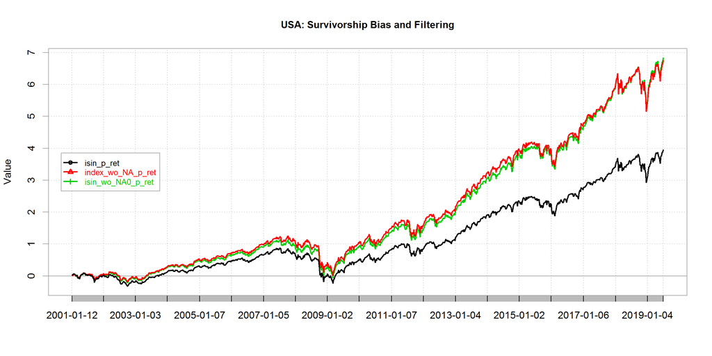

# USA. The MSCI index performance (Survivorship Bias and Filtering). Summary

- This chart represents the influence of the Survivorship (look-ahead) bias and the filtering effect.
- We can see that index w/o NA significantly outperforms equal-weighted original index. This difference represents the Survivorship (look-ahead) bias.
- This is caused by look-ahead bias, since investment is done only in strong companies.
- There is no noticeable difference in performance between red and green lines. This means that filtering does not help.
- However, there is the sampling bias. Here we check the filtering effect only among survived companies (sampling bias). There is no possibility to say anything about the influence of the filter on the companies, which are not survived.
- This means the filtering effect in this project is valid ONLY for survived (best, strongest) companies.

# EUR. The MSCI index performance (Original VS Equal-Weighted)

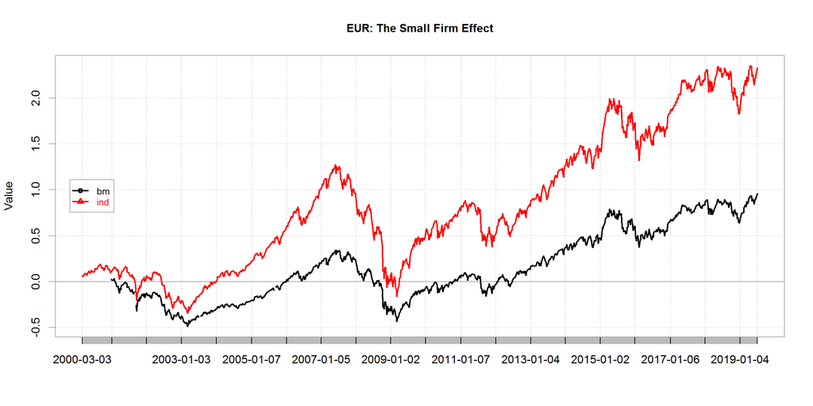

# EUR. The MSCI index performance (Original VS Equal-Weighted). Summary

- Equal-weighted index outperforms the original one almost 2 times.
- However, the index performs worse than in the U.S. market (also 2 times).

# EUR. The MSCI index performance (Survivorship Bias and Filtering)

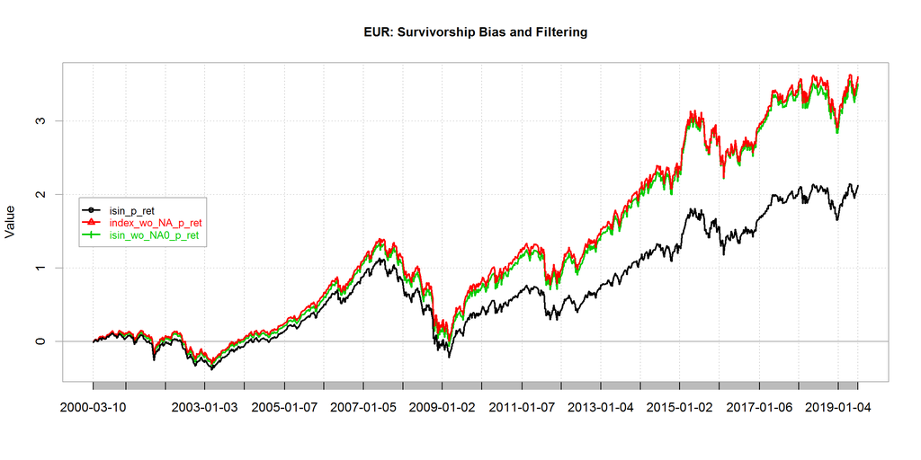

# EUR. The MSCI index performance (Survivorship Bias and Filtering). Summary

- The picture is fairly the same as in USA case: strong survivorship bias (1.5 times) and the filter does not influence the performance.
- The benchmark here is the equal-weighted original index.

# EM. The MSCI index performance (Original VS Equal-Weighted)

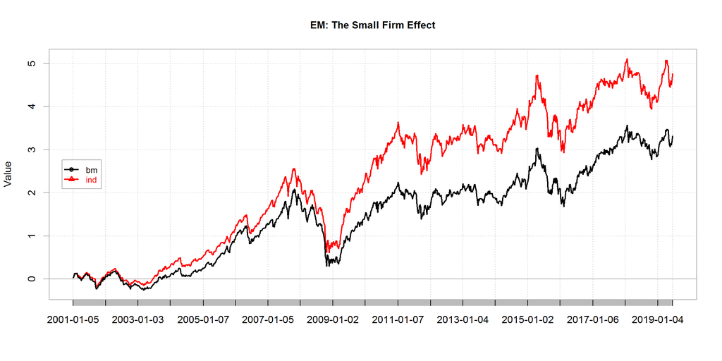

# EM. The MSCI index performance (Original VS Equal-Weighted). Summary

- The same picture: the equal-weighted index significantly (1.5 times) outperforms the original one.

# EM. The MSCI index performance (Survivorship Bias and Filtering)

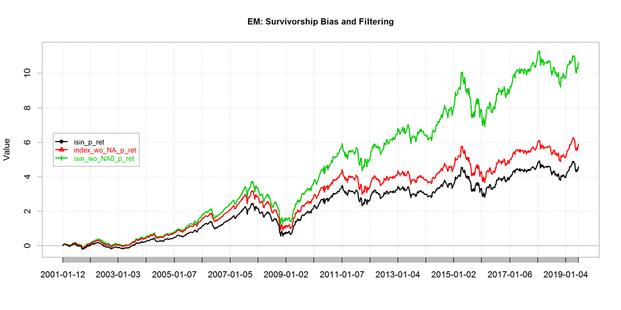

# EM. The MSCI index performance (Survivorship Bias and Filtering). Summary

- The survivorship bias here is also strong (1.5 times).
- Here filtering helps a lot (more than 1.5 times better than Survived portfolio).
- The benchmark here is the equal-weighted original index.

# JBonds. The MSCI index performance (Survivorship Bias and Filtering)

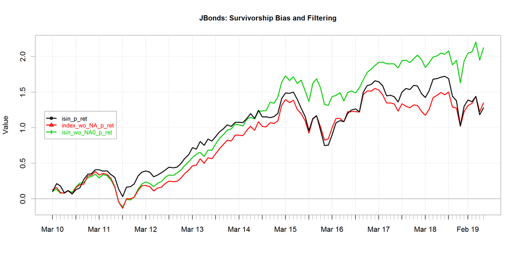

# JBonds. The MSCI index performance (Survivorship Bias and Filtering). Summary

- For Junk bonds there is no an original benchmark.
- The look-ahead bias does not help, meaning that equity performance does not really improve bond performance.
- Filtering also produces robust outperformance compared to the Survived case.
- The benchmark here is the equal-weighted original index.

# IGBonds. The MSCI index performance (Survivorship Bias and Filtering)

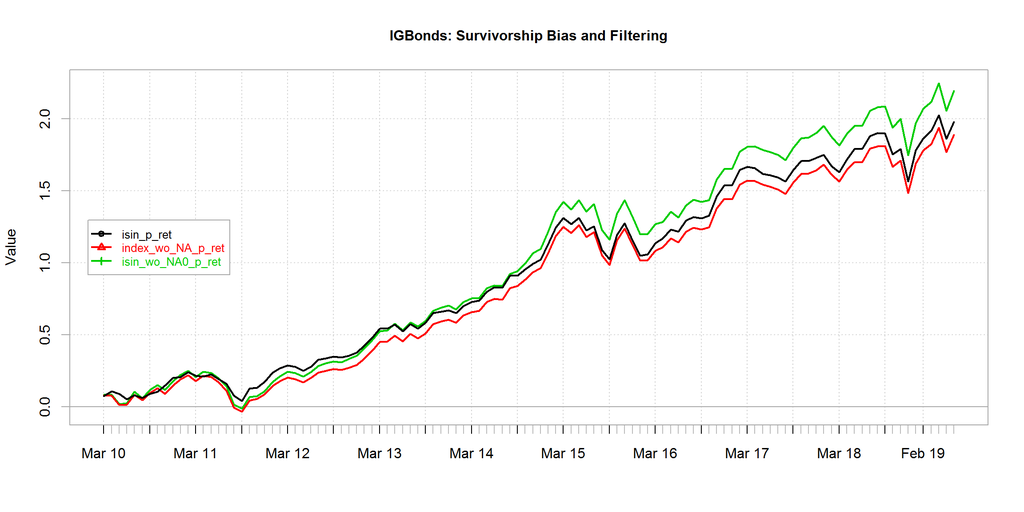

# IGBonds. The MSCI index performance (Survivorship Bias and Filtering). Summary

- For Investment Grade Bonds there is no an original benchmark.
- The Survivorship bias does not change the performance.
- Filtering also does not help much (“good” companies are a bit better). However, we can notice that green line is always a bit better than red line, meaning that the pattern is robust.
- The benchmark here is the equal-weighted original index.

# Conclusions Part 1:

- In the very end of the used period (w/o backward filling) the data demonstrate suspicious behavior.
- The equity data suffers from strong look-ahead (survivorship) bias.
- The look-ahead (survivorship) bias does not exist in JBons and IGBonds universes. It means that equity performance is not highly correlated with bonds performance.
- For equities equal-weighted index should be used as a benchmark (the difference is huge).
- Only in EM filtering helps significantly. There is also some help in JBons and IGBonds universes.

# Average Scores and Factors Construction Methodology

- The original scores are normalized in range [0,1]. Having 20% cutoff level, this means that average score for the long and the short sides of a portfolio must be roughly 0.9 and 0.1 correspondingly.
- The factors (value, momentum and size) are constructed as follows: first SustFilter is applied and after that 20% threshold. Then the long portfolio contains the top 20% (in terms of a score) of companies and short contains bottom 20%.
- Since the data contains the survivirship (look-ahead) bias the number of companies in the long and short parts are different and increasing with time.
- Moreover, until 2018 (after the data is not stable) the average score is expected to converge to 0.9 and 0.1, since more and more companies become available. This is valid only if the filter does not have a robust influence.

# USA. Average Scores. Momentum

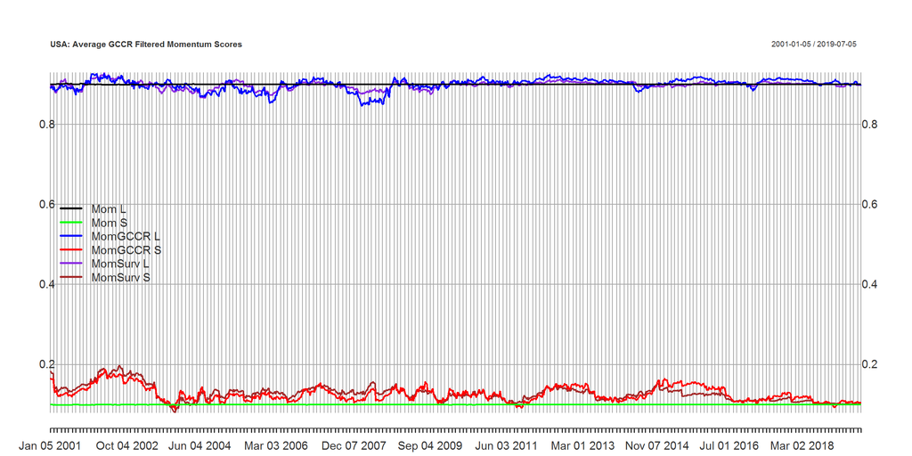

# USA. Average Score. Momemtum. Summary

- Survived (0 and 1): TOP: no significant effect, BOT: on average > 0.1 (0.13).
- Good (Only 1): TOP&BOT: no significant effect compared with the Survived case.
- These facts tell us that on average firms, which survive in the index, tend to have higher momentum score. This makes sence and goes along with the general idea of surviving in the index.

# USA. Average Scores. Size

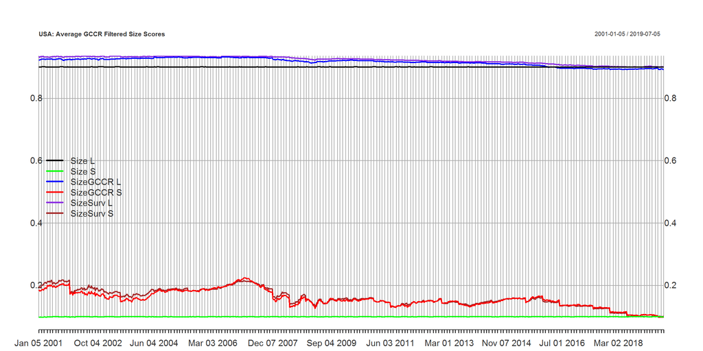

# USA. Average Score. Size. Summary

- Survived (0 and 1): Here the picture is even more robust: survived companies used to have higher size score, meaning that these companies were big (only the biggest survived).
- Good (Only 1): There is no effect.

# USA. Average Scores. Value

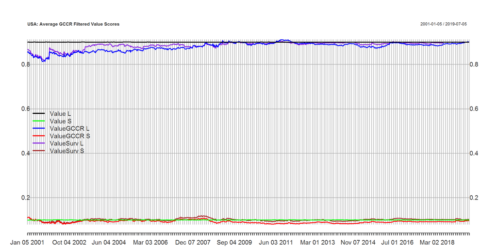

# USA. Average Score. Value.Summary

- Survived (0 and 1): Here we also have a consictent result for TOP: we know that for the last 10 years value factor has been performing bad, so this pattern is reflected here. The survived companies used to have smaller value scores, meaning that they were in some sence “more growth”.
- Good (Only 1): There is no effect.

# EUR. Average Scores. Momentum

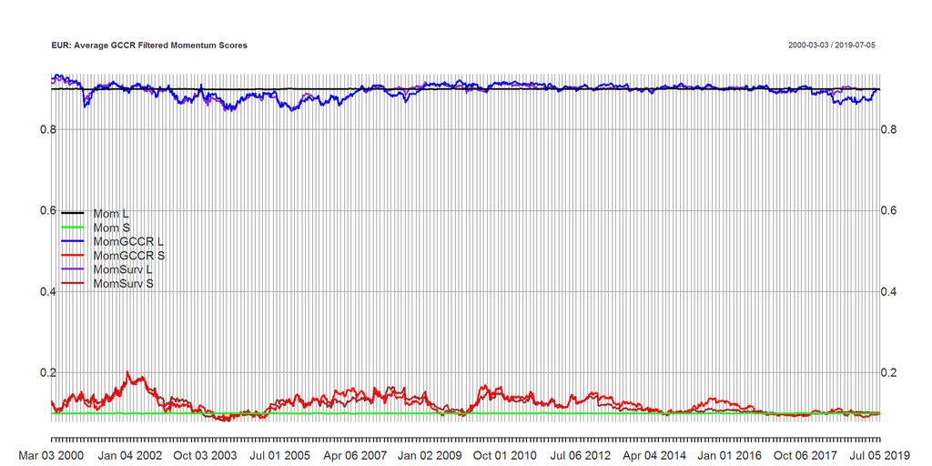

# EUR. Average Score. Momemtum. Summary

- Absolutely same results as in USA market.
- Survived (0 and 1): TOP: no significant effect, BOT: on average > 0.1.
- Good (Only 1): TOP&BOT: no significant effect compared with survived.
- These facts tell us that on average firms, which survive in the index, tend to have higher momentum score. This makes sence and goes along with the general idea of surviving in the index.

# EUR. Average Scores. Size

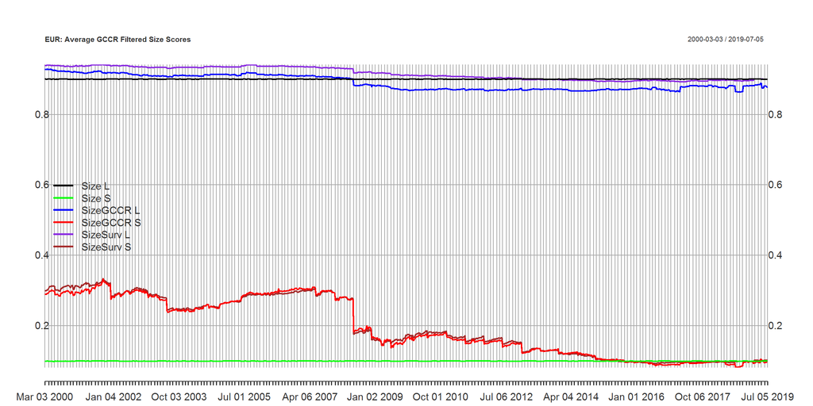

# EUR. Average Score. Size. Summary

- Survived (0 and 1): Here we can notice the smallest companies, which are still in index used to be bigger (quite logical). We also can see the drop in size in 2008.
- Good (Only 1): TOP: There is no convergence in the end. This means that filter eliminates some of the biggest companies. Moreover, this pattern is robust after 2008 (before the companies used to be relatively bigger). BOT: no effect.

# EUR. Average Scores. Value

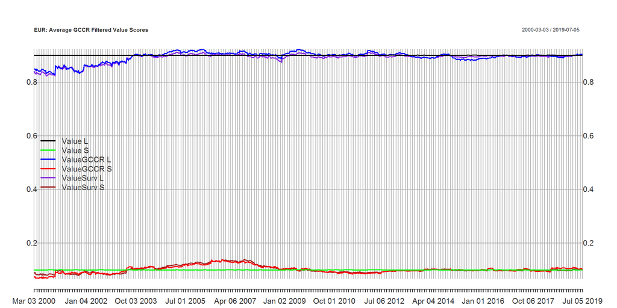

# EUR. Average Score. Value. Summary

# EM. Average Scores. Momentum

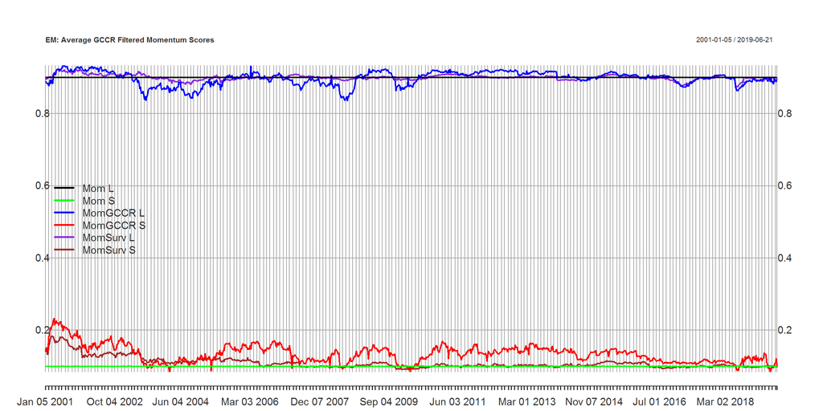